# Using adehabitatHR, adehabitatLT and sp packages to measure animal home range

## Introduction

Animal home ranges are the areas that animals use to carry out their normal day-to-day activities such as sleeping, feeding, and mating. There at two general classes of home range estimators: *Minimum Convex Polygon* (MCP) and *Kernel Density Estimator* (KDE) home range estimates.

In the first part of this tutorial, we will examine how to load data and let R know what it needs to know about the data.

In the second part we will calculate the MCP home ranges for Cape Buffalo in South Africa.

In the third part we will calculate KDE home ranges for the same Cape Buffalo.

In the final part, we will compare the MCP to KDE estimators to see the pros and cons of each.

So, let’s begin!

## Part 1 - Prepping the R workspace and the data

I like to begin any session in R with setting up a few features of the workspace and loading any packages that I will need.

```r
rm(list=ls()) #clear's the environment

#now install pacman package to check on what packages that you need are already installed and install them if not
if(!require("pacman")) install.packages("pacman")
pacman::p_load(dplyr, adehabitatHR, adehabitatLT, sp, ggplot2, magrittr, maptools) #checks to see if packages are installed and installs them if not

#now turn the packages on
library(dplyr)
library(tidyr)
library(adehabitatHR)
library(adehabitatLT)
library(sp)
library(rgdal)#won't load on rstudio server; used to apply datum, export .shp
library(ggplot2)
library(magrittr)
library(maptools)
library(tidyr)
library(sf)
library(here)
```

Ok, now that we’ve got stuff cleared, turned on, and ready to go, let’s load some data.

```r
CapeBuffalo <- read.csv(here("Mammalogy18", "SpaceUse", "Data", "CapeBuffalo", "Kruger African Buffalo, GPS tracking, South Africa.csv"))
```

Now let’s look at the data and see how they are organized

```r
structure(CapeBuffalo) #examines the structure of the dataset
```

| event.id | visible | timestamp | location.long | location.lat | algorithm.marked.outlier | external.temperature | manually.marked.outlier | sensor.type | individual.taxon.canonical.name | tag.local.identifier | individual.local.identifier | study.name | utm.easting | utm.northing | utm.zone | study.timezone | study.local.timestamp |
| --- | --- | --- | --- | --- | --- | --- | --- | --- | --- | --- | --- | --- | --- | --- | --- | --- | --- |
| 1930863794 | true | 2005-02-17 05:05:00.000 | 31.76642 | -24.53730 | NA | 24.3 | NA | gps | Syncerus caffer | T8 | Queen | Kruger African Buffalo, GPS tracking, South Africa | 375051.4 | 7285726 | 36S | South Africa Standard Time | 2005-02-17 07:05:00.000 |
| 1930863795 | true | 2005-02-17 06:08:00.000 | 31.76442 | -24.53931 | NA | 29.5 | NA | gps | Syncerus caffer | T8 | Queen | Kruger African Buffalo, GPS tracking, South Africa | 374850.8 | 7285502 | 36S | South Africa Standard Time | 2005-02-17 08:08:00.000 |
| 1930863796 | true | 2005-02-17 07:05:00.000 | 31.76114 | -24.54799 | NA | 35.8 | NA | gps | Syncerus caffer | T8 | Queen | Kruger African Buffalo, GPS tracking, South Africa | 374527.2 | 7284538 | 36S | South Africa Standard Time | 2005-02-17 09:05:00.000 |
| 1930863797 | true | 2005-02-17 08:05:00.000 | 31.76080 | -24.54703 | NA | 37.3 | NA | gps | Syncerus caffer | T8 | Queen | Kruger African Buffalo, GPS tracking, South Africa | 374491.6 | 7284644 | 36S | South Africa Standard Time | 2005-02-17 10:05:00.000 |
| 1930863798 | true | 2005-02-17 09:05:00.000 | 31.75982 | -24.54681 | NA | 38.9 | NA | gps | Syncerus caffer | T8 | Queen | Kruger African Buffalo, GPS tracking, South Africa | 374392.3 | 7284667 | 36S | South Africa Standard Time | 2005-02-17 11:05:00.000 |
| 1930863799 | true | 2005-02-17 10:05:00.000 | 31.75968 | -24.54680 | NA | 39.6 | NA | gps | Syncerus caffer | T8 | Queen | Kruger African Buffalo, GPS tracking, South Africa | 374378.0 | 7284668 | 36S | South Africa Standard Time | 2005-02-17 12:05:00.000 |
| 1930863800 | true | 2005-02-17 11:05:00.000 | 31.76011 | -24.54682 | NA | 40.0 | NA | gps | Syncerus caffer | T8 | Queen | Kruger African Buffalo, GPS tracking, South Africa | 374421.5 | 7284666 | 36S | South Africa Standard Time | 2005-02-17 13:05:00.000 |
| 1930863801 | true | 2005-02-17 12:05:00.000 | 31.76019 | -24.54685 | NA | 38.1 | NA | gps | Syncerus caffer | T8 | Queen | Kruger African Buffalo, GPS tracking, South Africa | 374429.8 | 7284663 | 36S | South Africa Standard Time | 2005-02-17 14:05:00.000 |
| 1930863802 | true | 2005-02-17 13:05:00.000 | 31.76015 | -24.54686 | NA | 38.5 | NA | gps | Syncerus caffer | T8 | Queen | Kruger African Buffalo, GPS tracking, South Africa | 374425.7 | 7284662 | 36S | South Africa Standard Time | 2005-02-17 15:05:00.000 |
| 1930863803 | true | 2005-02-17 14:05:00.000 | 31.76318 | -24.54720 | NA | 38.9 | NA | gps | Syncerus caffer | T8 | Queen | Kruger African Buffalo, GPS tracking, South Africa | 374732.9 | 7284627 | 36S | South Africa Standard Time | 2005-02-17 16:05:00.000 |

[output cut: 990 more lines]

Now let’s plot the data

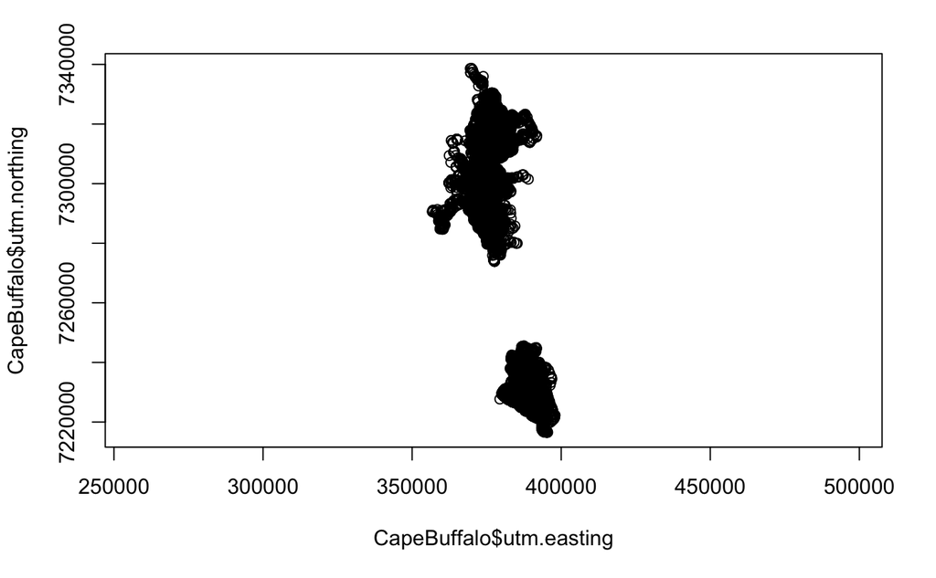

```r
plot(CapeBuffalo$'utm.easting', CapeBuffalo$'utm.northing', asp = 1)
```

```r
#subset DF to get just animal name, X and Y coords

Data<-CapeBuffalo %>% dplyr::select('utm.easting', 'utm.northing', `individual.local.identifier`)

str(Data)
```

```
'data.frame':   24653 obs. of  3 variables:
 $ utm.easting                : num  375051 374851 374527 374492 374392 ...
 $ utm.northing               : num  7285726 7285502 7284538 7284644 7284667 ...
 $ individual.local.identifier: chr  "Queen" "Queen" "Queen" "Queen" ...
```

Now let’s tell R that the utm coordinates represent spatial and not just numeric information.

```r
sp::coordinates(Data)<-Data[,c("utm.easting", "utm.northing")]
```

Ok! Our data are ready, so we can move on to Part 2!

## Part 2 - Calculate the MCP home ranges for the buffalo.

First, let’s see how many buffalo are in our dataset by examining the ’individual.local.identifer (aka Name). To do so, we need to change the names from character variables to factor variables.

```r
#change from character to factor
Data$individual.local.identifier<-as.factor(Data$individual.local.identifier)

#now see how many levels of the factor there are
levels(Data$individual.local.identifier)
```

```
[1] "Cilla"  "Gabs"   "Mvubu"  "Pepper" "Queen"  "Toni"
```

Looks like there are 6 buffalo in our data set.

Often, when we estimate MCP or any other home range, we like to examine the home range size with a variety of the whole data set.

[figure not shown]

Now use the sf package to write the shapefiles.

```r
sf::st_write(as(mcp_est100, "sf"), here("Mammalogy22", "Data", "Shapefiles", "MCP100.shp"))

sf::st_write(as(mcp_est90, "sf"), here("Mammalogy22", "Data", "Shapefiles", "MCP90.shp"))

sf::st_write(as(mcp_est80, "sf"), here("Mammalogy22", "Data", "Shapefiles", "MCP80.shp"))

sf::st_write(as(mcp_est70, "sf"), here("Mammalogy22", "Data", "Shapefiles", "MCP70.shp"))
```

Now let’s get the areas of the home ranges

```r
MCP_areas<-as.data.frame(mcp_est100)
MCP_areas
```

|  | id | area |
| --- | --- | --- |
| Cilla | Cilla | 324.1863 |
| Gabs | Gabs | 210.3761 |
| Mvubu | Mvubu | 294.0577 |
| Pepper | Pepper | 943.7987 |
| Queen | Queen | 582.1266 |
| Toni | Toni | 369.8555 |